# Assignment 3: Data Visualization

John Nguyen

02/26/2022

# Report

**Proportion of Population is Asian American/Pacific Islander:**

## Introduction

Being of asian descent and living in washington state all my life I am curious about how the proportion of jail population differs for Asian Americans/Pacific Islanders and Blacks in Washington State. To answer my questions, I will analyze the incarceration dataset; mainly looking at: total population per county between the age of 15 to 64, total Black and AAPI population per county, total jail population per county, and Black and AAPI jail population.

## Summary

**Average Proportion of Total Population being Asian American/Pacific Islander vs Black (Per County in Washington State)**  
**AAPI:** 0.0405  
**Black:** 0.0221

**Average Proportion of Jail Population being Asian American/Pacific Islander vs Black (Per County in Washington State)**  
**AAPI:** 0.0165  
**Black:** 0.066

**Highest Proportion of Jail Proportion being Asian American/Pacific Islander vs Black (Per County in Washington State)**  
**AAPI:** 0.0538  
**Black:** 0.3085

## Trends

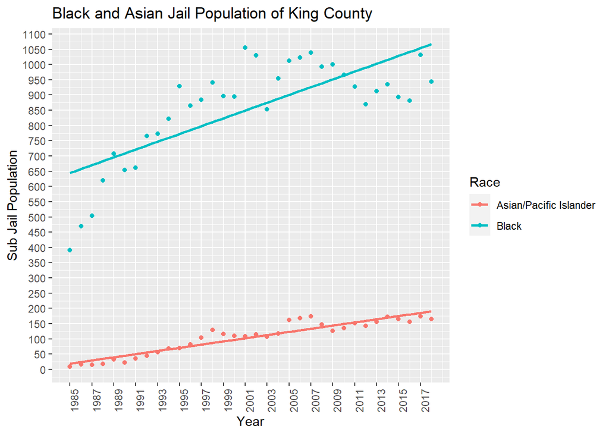

This chart allows us to easily see the change in Black and Asian/Pacific Islander jail populations in King County over time. From the visual, we can see that the Black jail population is much greater and grows more rapidly than the Asian/Pacific Islander jail population. Looking at spread in the data, it seems that the Asian/Pacific Islander jail population is growing at a more steady rate whereas the Black jail population increases and decreases more sporadically.

## Chart

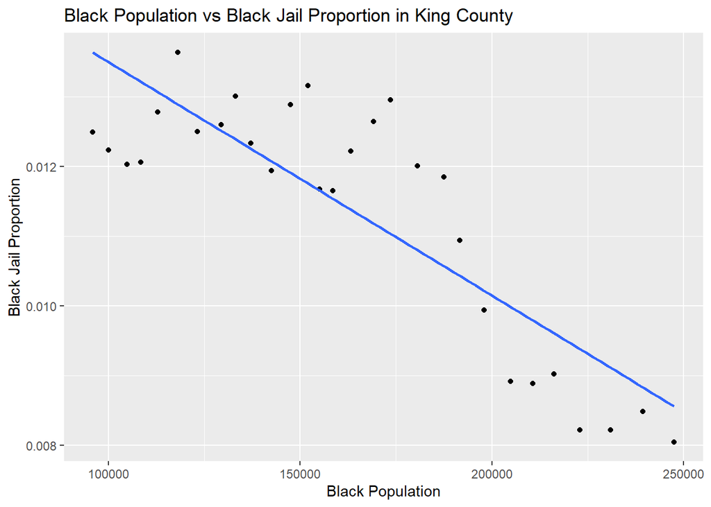

From the previous visualization, I was able to see that the black jail population was increasing over time. Due to knowing this fact, I became curious as to whether or not the black jail proportion was increasing over time. Another factor that has been increasing over the years was the black population. I wanted to see whether or not there was a correlation between the growth of the black population and the growth of the black jail proportion. Based on the visual, there seems to be a negative correlation between the black jail proportion and the black population. As one increases the other decreases.

## Map

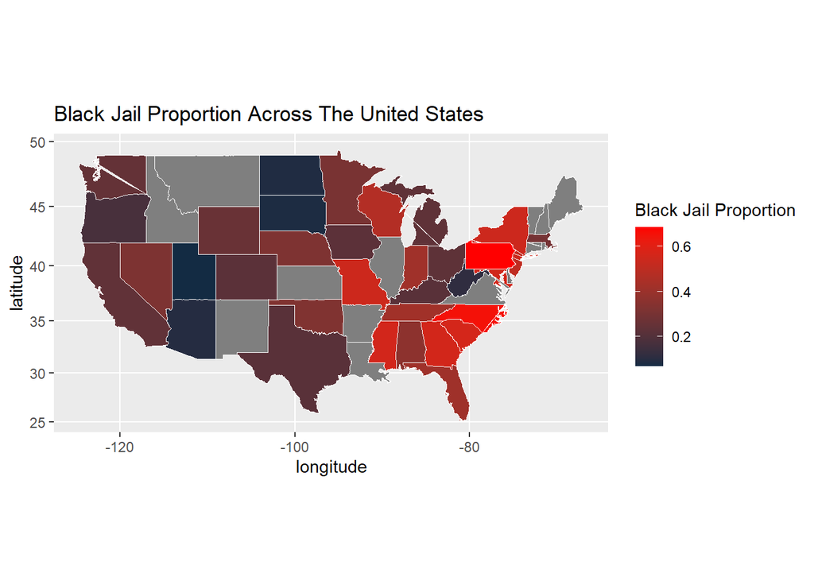

I included this chart because in the previous sections, my analysis solely focused on Washington state data. I was curious as to how the black jail proportion of Washington state compared to the other states. Looking at the chart, you can see that all the states that have the highest black jail population proportions are on the eastern side of the country. Those that have unavailable data are on are painted gray.